# Intro to RNA-seq

10/13/2020

## Schedule

- Overview on RNA-seq
- How to perform transcript quantification with Salmon
- Using R for making Plots
- Exploring RNA-seq data
- Differential Gene expression

## RNA Biology - The Central Dogma

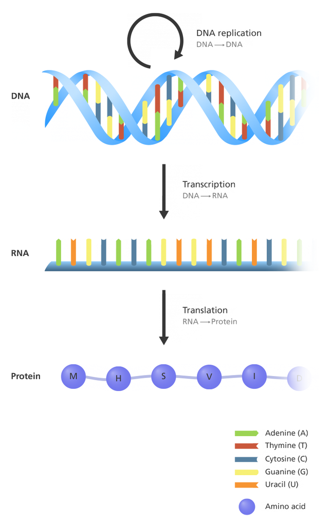

- In transcription, distinct parts of the genome are transcribed into immature RNA.

## RNA processing

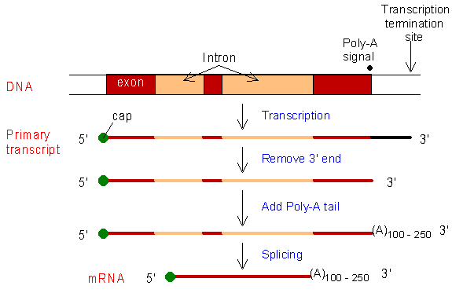

- RNA processing mechanisms convert immature RNA to mature RNA (mRNA)
- RNA processing mechanisms include polyadenylation and splicing
- Exons - regions of immature RNA that are retained in mRNA
- introns - regions of immature RNA that are **NOT** retained in mRNA

## One gene, multiple isoforms

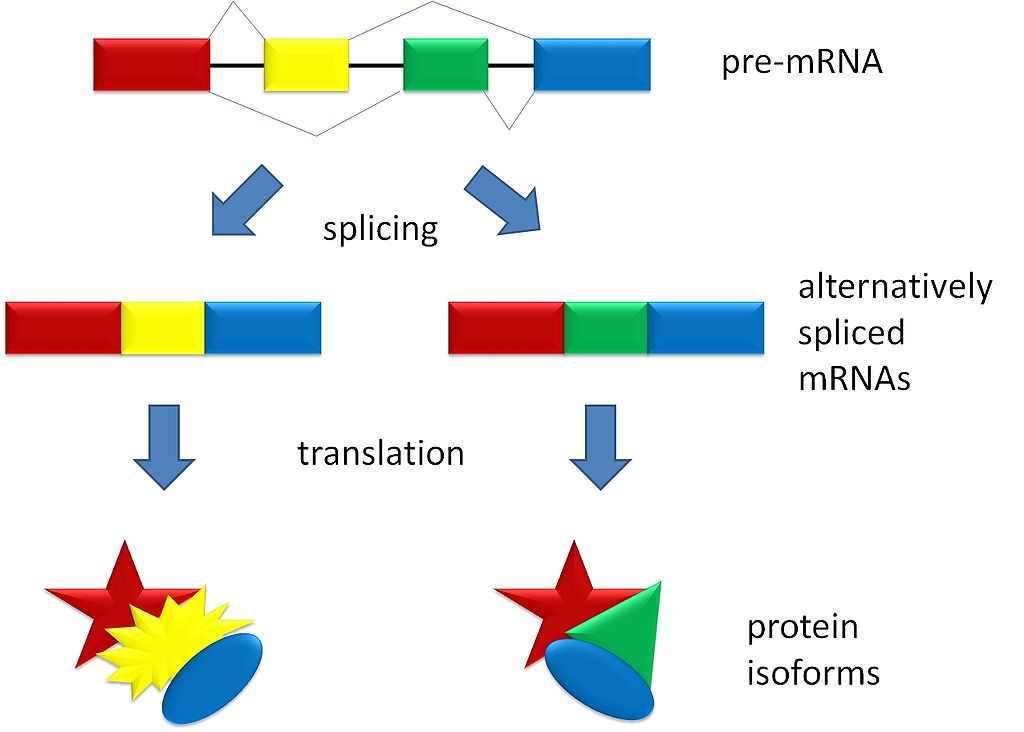

- the locus associated with a single gene often leads to multiple distinct isoforms
- This occurs because each RNA processing mechanism can lead to the formation of different gene isoforms
- For example, alternative splicing leads to the inclusion/exclusion of different exons, and can lead encoded proteins with distinct functions
- mRNA transcripts are the distinct units of transcription, not genes

## High throughput RNA sequencing - RNA-seq

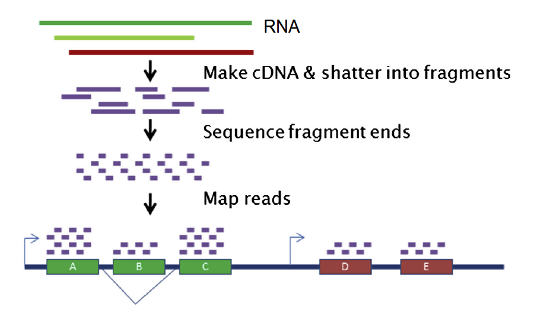

- In RNA-seq, mRNA transcripts are converted to cDNA
- cDNA is fragmented. Steps up to here are commonly referred to as library preparation
- Fragments are amplified with PCR and then sequenced. Each PCR cycle there is a chance of introducing errors
- Amplified fragments are called “Reads”. Reads are typically 50-150bp long. Generally there’s around 50 Million reads per sample
- reads are then computationally assigned to the original mRNA transcript they come from

## Library Selection Method

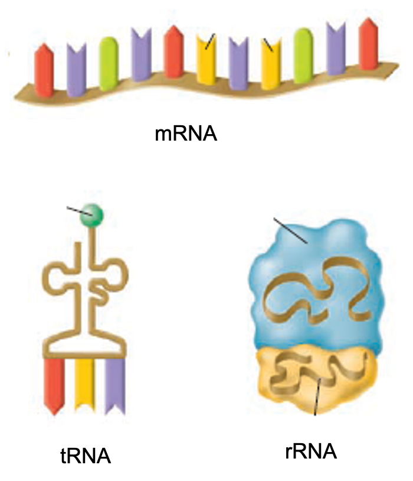

- There are multiple types of RNA
- RNA-seq generally refers to mRNA only, so part of the library prep procedure is to remove unwanted types
- polyA selection
  - pros: cheap, and efficient. Most commonly used method
  - cons: removes ncRNA and introduces a bias for the 3’ end of transcripts
- riboRNA(rRNA) depletion
  - pros: only removes rRNA and tRNA, no coverage bias, useful for prokaryotic organisms
  - cons: expensive

## The Spliced alignment problem

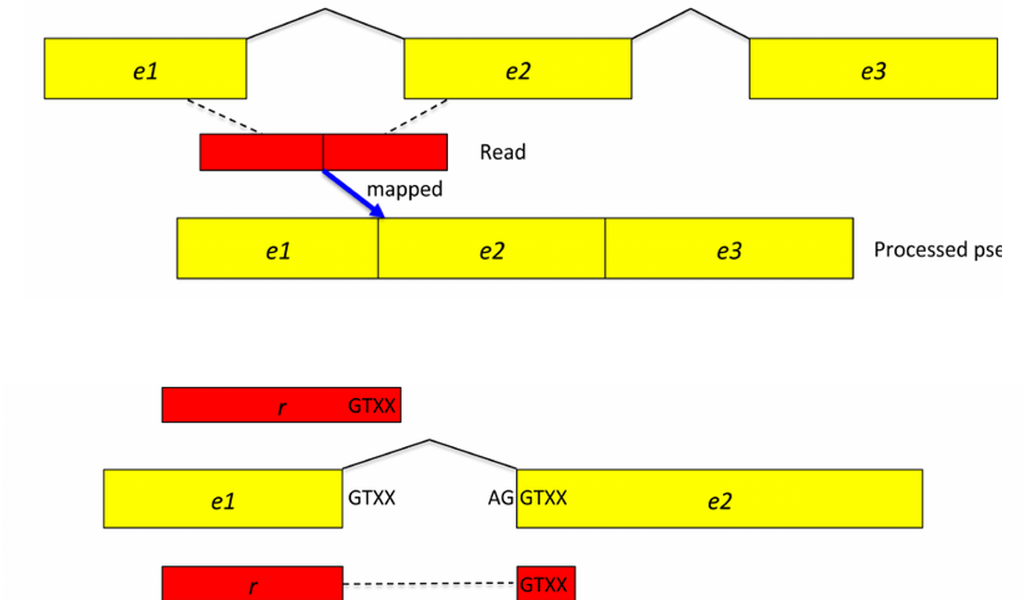

- The challenge with aligning RNA-seq reads arises from the fact that reads spanning exon-exon junctions can’t be directly mapped to the genome
- aligners for RNA-seq most account for this problem, often at the expense of increased computing resources
- typical spliced aligners: TopHat, STAR, Hisat2
- these tools align reads to the genome

## Library Type

- stranded OR
- unstranded AND
- single OR
- paired

## Transcript Quantification

- With transcript quantification, reads are assigned to individual mRNA transcripts, not the genome. This eliminates the spliced alignment problem
- In transcript quantification, reads are not precisely aligned, but rather are assigned to where they most likely should be aligned (pseudoalignment)
- Early iterations of transcript aligners were not as accurate as conventional genome based alignment, but newer versions have been show to as accurate as genome based alignment
- Transcript quantification requires **significantly** fewer resources than spliced alignment.
- typical tools: Salmon, Kallisto. We’ll be using salmon for this course

## Preparing an Index for Salmon

- the index is a computationally efficient representation of the distinct RNA transcripts in `transcripts.fa`
- the index preparation for Salmon is slightly different, and requires the preparation of decoy sequences. decoy sequences improve the accuracy of transcriptome quantification

```bash
grep "^>" genome.fa | cut -d " " -f 1 | sed  -e 's/>//g'  > decoys.txt # get names of chromosomes
cat transcripts.fa genome.fa > transcript_genome_merged.fa # merge two fastas together
salmon index -t gentrome.fa.gz -d decoys.txt -p 12 -i salmon_human_index --gencode # use salmon to build the index
```

## Quantifying Transcripts

- We next use our index and fastq files(s) for quantification
- This is a typical command

```bash
salmon quant  \
  --threads 8 \ # number of process to use
  --libType A \  # stranded or unstranded library. Use "A" to allow salmon to infer
  -1 sample_left.fq \ # fastqs; use "-r sample.fq" for single end data
  -2 sample_right.fq \
  --index salmon_human_index \ # name of th index we built earlier
  --seqBias \ # Perform sequence-specific bias correction.
  --gcBias \  # Perform fragment GC bias correction.
  --posBias \ # Perform positional bias correction.
  --output sample_quantified/ # output folder. the actual file with the quantification will be named "quant.sf"
```

## Output

- the `quant.sf` file produced looks something like this

| Name | Length | EffectiveLength | TPM | NumReads |
| --- | --- | --- | --- | --- |
| DNTX_00000017 | 12501 | 9261.044 | 2.532237 | 2529.632 |
| DNTX_00000019 | 3218 | 1783.769 | 12.960541 | 2493.762 |
| DNTX_00000020 | 39670 | 27993.255 | 1.370513 | 4138.375 |
| DNTX_00000018 | 26868 | 17512.212 | 2.156619 | 4073.875 |
| DNTX_00000034 | 12032 | 7527.305 | 0.713575 | 579.392 |
| DNTX_00000033 | 8417 | 6031.772 | 0.725138 | 471.801 |
| DNTX_00000035 | 3349 | 1579.033 | 3.459229 | 589.201 |

## Analysis of RNA-seq data in R

- R is the most common language for (bulk)RNA-seq analysis by a wide margin
- Most of the packages for RNA-seq analysis are hosted on `Bioconductor`, which is a repository similar to CRAN, but more biologically focused.
- we can get access to `Bioconductor` by installing the `BiocManager` library

```r
install.packages('BiocManager')
```

- we can then use `BiocManager::install` to download packages from `Bioconductor`

## Analysis of RNA-seq data in R

- there are a *lot* of tools for analyzing RNA-seq data.
- We’ll be covering `DESeq2` for this course, because it is by far the simplest to use
- tools like `edgeR` and `limma` are a little more powerful, but are harder to use.
- download `DESeq2` with `BiocManager::install('DESeq2')`

## Normalization of RNA-seq data

- Normalization of RNA-seq data is a *critical* step for its analysis
- Aligned RNA-seq data is presented as counts, where each read is a single count
- The two most important parts of RNA-seq normalization is “between-sample normalization” and “between transcript normalization”

## Between Sample Normalization

- Library size refers to the number of reads in a given sample
- Library size is generally not indicative of the total amount of gene expression within the sample, but is influenced heavily by the PCR amplification step
- And so when we compare samples we want to ensure that the number of reads is uniform across samples

## Between transcript normalization

- mRNA transcripts have a wide range of lengths, and the number of counts per transcript is *directly* correlated with transcript length
- Consider two transcripts, A and B.
  - A and B are expressed at the exact same levels .A is 1000 bp long, and B is 10000bp long.
  - We divide each transcript into uniform 100bp fragments, producing 10 fragments for A(1000/100 = 10) and 100 fragments for B (10000/100 = 100)
  - We then each amplify each fragment 100 times. For A this gives 10 x 100 = 1000 reads, and for B this gives 100 *100 = 10000 reads
  - And so despite being expressed at the same level, transcript B has more counts and appears to be expressed higher.
  - to combat this, we normalize the expression of each transcript by its length. For A this is 1000 reads/ 1000 bp = 1, and B 10000 reads/ 10000bp = 1

## Transcripts per Million reads (TPM)

- Combines both normalization methods, accounting for both transcript length and library size
- Formally Let TPM is \(TPM_t= \frac{c_t/l_t}S * 1000000\) where
  - \(S=\sum_{t\ \in\ T} c_t/l_t\)
  - \(c_t\) = total number of counts(reads) for a transcript *t*,
  - \(l_t\) = length of *t* in kilobases
  - \(T\) = all transcripts quantified in the entire sample
- TPM values are provided as part of Salmon’s output

## RNA-seq analyses methods use more robust methods for normalization

- RNA-seq analysis tools like `edgeR` and `DESeq2` use a more sophisticated approach for normalization, but generally follow the principles mentioned earlier
- Because of this, **ALWAYS** pass *raw* counts to these tools, and allow them to normalize for you

## Metadata

- For RNA-seq tool, you will need metadata about your samples; At the very least the metadata should include the sample names and experimental conditions.

| sample | cell_line | treatment |
| --- | --- | --- |
| SRR1039508 | N61311 | untrt |
| SRR1039509 | N61311 | trt |
| SRR1039512 | N052611 | untrt |
| SRR1039513 | N052611 | trt |
| SRR1039516 | N080611 | untrt |
| SRR1039517 | N080611 | trt |
| SRR1039520 | N061011 | untrt |
| SRR1039521 | N061011 | trt |

## Metadata

- it can also be useful to add paths to each file in the metadata file, so you can remember where they are on your computer

## Reading RNA-seq data into R

- the `tximport` package provides a uniform interface to read RNA-seq data into R.
- It also can aggregate transcript level expression to gene level expression.
- install the required packages this with `BiocManger::install(c('tximport', 'rtracklayer'))`

## Using `tximport`

```r
library(tximport)
tximport(
    files, # a vector containing file paths to your "quant.sf" files
    type, # the type of tools used to generate the data ie "salmon" or "kallisto"
    txOut,# whether or not to return transcript level expression
    tx2gene,# a dataframe that maps transcript_id (first column) to gene_ids (second column)
    ignoreTxVersion# many transcript id's are versioned based on release.
                   # set this to true to ignore versions
)
```

## Creating a `tx2gene`

- many tutorials recommend getting annotations through R-based tools, like `BiomaRt`
- I’ve found that its much easier to simply download the appropriate transcript annotation file(.GTF) from the same source you obtained your transcript fasta from
- for example with, [gencode](https://www.gencodegenes.org/human/)
- gtfs can be read directly in R to with the `rtracklayer` package

```r
library(dplyr)
gtf <- rtracklayer::readGFF('path/to/gtf')
tx2gene <- gtf %>%
  filter(type == 'transcript') %>%
  select(transcript_id, gene_id) %>%
  distinct()
```

## Gene level vs Transcript level expression

- It’s much easier to work with gene level data than transcript level data
- We’ll cover working with gene level data first, and if we have time discuss working with transcript level data

## Loading data into `DESeq2`

- DESeq2 allows you to load data directly using the output of tximport

```r
library(DESeq2)
DESeqDataSetFromTximport(
  txi = # the  output from
  colData = # a data fram containing metadata about each sample
  design = # the experimental design of the study. Must be a column in metadata
  )
```

## Study Designs

- A study design is based on the experimental conditions you are testing.
- In R, this is a vector of conditions that corresponds to experimental condition of each sample.

```r
samples$condition
```

```
## [1] A A A B B B
## Levels: A B
```

- the design vector must be a column in the `colData` dataframe, and we refer to designs using the `~` operator,
- the design is used to signify that the variation in the observed in the data can best described by the design vector

```r
ddsTxi <- DESeqDataSetFromTximport(txi,
                                   colData = samples,
                                   design = ~condition)
```

```
## using counts and average transcript lengths from tximport
```

## Working with `DESeqDataSet` objects

- `DESeq` uses a custom type of R object called a `DESeqDataSet`

```r
class(ddsTxi)
```

```
## [1] "DESeqDataSet"
## attr(,"package")
## [1] "DESeq2"
```

- this a fancy container to store multiple levels of data using the `$` operator on a `DESeqDataSet` object allows you to access columns in the dataframe you passed to colData

```r
ddsTxi$condition
```

```
## [1] A A A B B B
## Levels: A B
```

## Working with `DESeqDataSet` objects

- raw counts can be accessed with the `assay` function

```r
head(assay(ddsTxi))
```

```
##                    ERR188297 ERR188088 ERR188329 ERR188288 ERR188021 ERR188356
## ENSG00000000003.14         3         2        27         8         5         6
## ENSG00000000005.5          0         0         0         0         0         0
## ENSG00000000419.12      1057      1338      1453      1289       921      1332
## ENSG00000000457.13       463       499       561       386       532       542
## ENSG00000000460.16       634       418      1170       611       916       637
## ENSG00000000938.12      2616      3698      3110      2690      1897      1911
```

## Analysis with `DESeq2`

- The general workflow of an analysis in RNA-seq experiment is the following
  - prefilter data
  - normalize for library size
  - account for technical variation
  - transforms count data
  - explore data
  - test for differential expression

## prefiltering data

- this step removes genes that have few counts. This is a always a good step, as it improves the statistical power of your tests,

```r
dim(ddsTxi)
```

```
## [1] 58288     6
```

```r
minimally_expressed <- rowSums(assay(ddsTxi)) >=25
ddsTxi_filtered <- ddsTxi[minimally_expressed,]
dim(ddsTxi_filtered)
```

```
## [1] 20648     6
```

## library size calculations

```r
dds <- estimateSizeFactors(ddsTxi_filtered)
```

```
## using 'avgTxLength' from assays(dds), correcting for library size
```

- `DESeq` first calculates the library size. Remember that this is analogous to the total number of per sample
- the count data is then scaled based on library size

## Estimating Dispersions

```r
dds <- estimateDispersions(dds)
```

- This is basically accounting for technical variability between expression of individual genes(its actually lot more complicated than that but beyond the scope of this course)
- for a more through explanation, see the documentation for the `estimateDispersions` function

## Transforming Count Data

- raw RNA-seq counts are good for statistical models, but bad for visualization. These counts are typically transformed to reduce the large range between count values for different genes
- This is typically done by `log2` transforming the counts, ie `log2(counts + 1)`.
- The 1 is added so counts less than stay above 0

## Transforming Count Data with DESeq2

- `DESeq` provides a slightly fancier way to log transform called `rlog`

```r
rlds <- rlog(dds)
```

- note that this returns a separate object than what we used earlier/ will use for differential expression

## Exploring data

- At this stage, we can begin exploring data.
- This is generally a QC step, to make sure that the data looks clean.

## A quick primer on dimensions

- Generally, when people refer the “dimension” of data, they refer to the number of measurement, or variables, within the data
- We’ll be using qPCR as an example. Lets say I measure the expression of 1 gene across 2 conditions,

```r
exp
```

```
## # A tibble: 6 x 3
##   Condition Replicate  Gene_A
##   <chr>         <int>   <dbl>
## 1 wt                1  0.0933
## 2 wt                2  1.30
## 3 wt                3  0.177
## 4 ko                1  0.345
## 5 ko                2  1.15
## 6 ko                3 -0.565
```

- this data has 6 observations, with 1 measurement, Gene_A, and so has one dimension

## A quick primer on dimensions

```r
exp2
```

```
## # A tibble: 6 x 4
##   Condition Replicate  Gene_A Gene_B
##   <chr>         <int>   <dbl>  <dbl>
## 1 wt                1  0.822   1.18
## 2 wt                2 -0.586   0.688
## 3 wt                3  0.942   2.72
## 4 ko                1  0.676   2.95
## 5 ko                2 -0.0642  0.930
## 6 ko                3  1.96    1.29
```

- Same number of observations, but with 2 measurement, and so this data has two dimension
- And so in a typical RNA-seq experiment where you are measuring 20K genes, you would have 20K dimensions
- However, note that RNA-seq is stored as variables x observations ( gene x sample)

## Exploring data with Principal Component Analysis

- Principal Component Analysis(PCA) is a method for reducing the dimensions from the data
- PCA computes a reduced dimensional space that maximally preserves the variation present in the original data.
- We can use this reduced dimensional space to speed up computations, or for visualizations

## PCA in DESeq2

- generating PCA plots is built into DESeq2. Simply pass a transformed data object to `plotPCA`

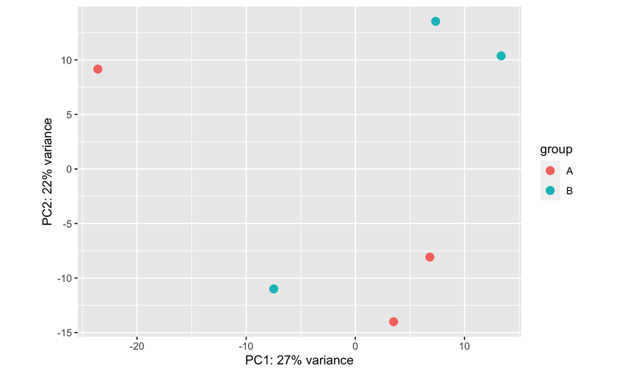

```r
plotPCA(rlds)
```

## Caution in interpreting PCA plots

- Always pay attention to the amount of variance in each principal component

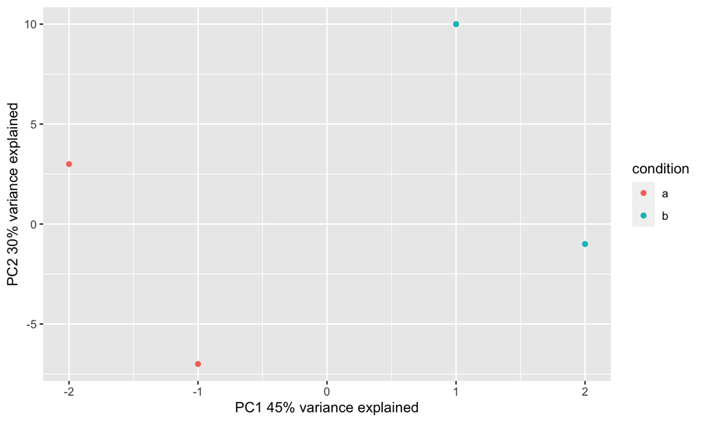

```r
library(ggplot2)
df <- tibble(x=c(-7, 3, -1, 10),
       y=c(-1,-2, 2, 1 ),
       condition = c('a', 'a', 'b', 'b'))
ggplot(df) +
  geom_point(aes(x=y, y=x, color = condition)) +
  xlab('PC1 45% variance explained') +
  ylab('PC2 30% variance explained')
```

## Correlation Heatmaps

- Correlation heatmaps are a more quantitative way to examine similarity between samples
- in a correlation heatmap, a correlation is calculated pairwise between samples
- correlations are a measure of similarity between samples. 1 is a perfect positive correlation, and -1 is a perfect negative correlation

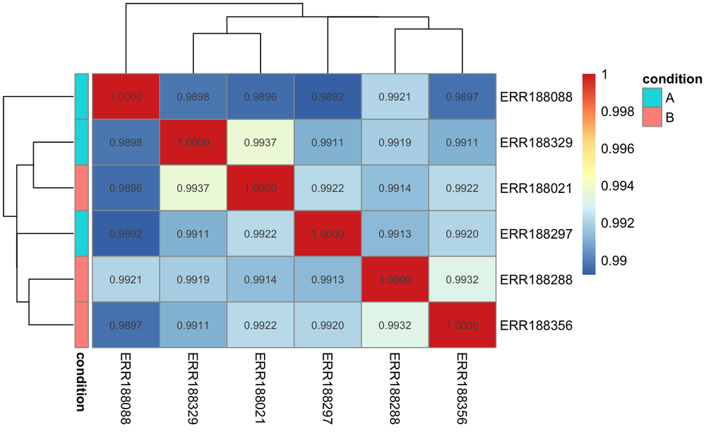

```r
suppressMessages(library(pheatmap))
cor_mat <- rlds %>% assay %>% cor( method = 'spearman')
# this is the same as cor(assay(rld))
pheatmap(cor_mat,
         display_numbers = T,
         number_format='%.4f',
         annotation_row = samples %>% select(condition))
```

## Correlation Heatmaps

- Because you get a quantitative measure of how similar samples are to each other, this is generally better for QC than PCA

## Testing For Differential Expression

- Differential expression is a statistical method for calculating whether the change in a gene’s expression between two conditions is statistically significant
- there are a couple key ideas to consider

## The actual statistical test

- The actual testing is done by fitting a linear model to the data, and then applying a statistical test to this model.
- There are multiple statistical tests you can use once this model is fit, the one I prefer is the Likelihood ratio test
- The likelihood model compares the a model with the design you specified (`~condition`) aka the full model, to a second model, aka the reduced. At its simplest level this model is just ~1, which means that the best way to describe the data is no model, ie there is just random variation in the data.

## The actual statistical test

```r
dds <-nbinomLRT(dds, full = design(dds), reduced = ~1)
```

- we can access the results using the `results` function

```r
diff_exp_results <-  results(dds) %>% as.data.frame
head(diff_exp_results)
```

```
##                       baseMean log2FoldChange     lfcSE       stat     pvalue
## ENSG00000000003.14    7.792025    -1.06897683 1.1261582 0.89452719 0.34425342
## ENSG00000000419.12 1231.738667    -0.17557873 0.2726684 0.41437365 0.51975792
## ENSG00000000457.13  498.729345    -0.16337605 0.2777701 0.34567353 0.55657252
## ENSG00000000460.16  715.477840    -0.06447702 0.3621231 0.03171165 0.85866200
## ENSG00000000938.12 2694.975263    -0.55436001 0.3356108 2.71177073 0.09961037
## ENSG00000001036.13  812.188338    -0.47134231 0.2438039 3.72196363 0.05370118
##                         padj
## ENSG00000000003.14 0.9986429
## ENSG00000000419.12 0.9986429
## ENSG00000000457.13 0.9986429
## ENSG00000000460.16 0.9986429
## ENSG00000000938.12 0.9794066
## ENSG00000001036.13 0.9202341
```

## How to pick differentially expressed genes

- the two major criteria for considering a gene as differentially expressed are the adjusted p-value(padj) and fold change
- fold change is the expression of GeneA_conditionX / GeneA_conditionY.
- We take the log of this value, so cases where GeneA_conditionX < GeneA_conditionY become negative and are on a similar scale as positive fold change
- A gene is differentially expressed if its pvalue is less than a specified value, and the absolute value of the log2fc is greater than a specified value

## selecting differentially expressed genes

```r
pvalue_cutoff = .05
l2fc_cutoff = 2
diff_exp_filtered <-  diff_exp_results %>%
  rownames_to_column('gene_id') %>%
  filter(padj < pvalue_cutoff,
         abs(log2FoldChange) > l2fc_cutoff)
head(diff_exp_filtered)
```

```
##              gene_id  baseMean log2FoldChange     lfcSE     stat       pvalue
## 1 ENSG00000099139.13  57.22273       2.697188 0.5446384 22.67705 1.916436e-06
## 2 ENSG00000138771.14 174.99397       2.754805 0.4763293 29.96474 4.399740e-08
## 3 ENSG00000160221.16 342.25484      -2.553766 0.5857181 17.09556 3.554525e-05
## 4 ENSG00000163564.14  60.79038       2.661380 0.5712845 20.09390 7.373146e-06
## 5 ENSG00000188681.11 215.78426      -2.657314 0.5120664 24.21264 8.626444e-07
## 6  ENSG00000211595.2  18.84828       3.187384 0.7866979 16.16736 5.798467e-05
##           padj
## 1 0.0028526886
## 2 0.0002128484
## 3 0.0299059217
## 4 0.0089173590
## 5 0.0018547814
## 6 0.0448824556
```

- you can choose basically any value for `pvalue_cutoff` and `l2fc`

## some caveats for RNA-seq

- RNA-seq is by no means a definitive measure of gene expression. While it can be highly accurate, its equally as error prone
- RNA expression levels do not always line up with protein
- Always let biology inform your decision making when working with RNA-seq.
- For example, if you have samples for different experimentally different that are biologically distinct IE morphologically, molecularly, functionally, etc, but the RNA-seq data doesn’t exactly match that up, run an analysis again with more relaxed filtering values.

## Downstream of DGE

- We can use these differential expression results for gene set enrichment or for visualization
- Gene set enrichment determines how many of your differentially expressed genes are in a list of genes that correspond to a specific biological process or function.
- Gene set enrichment is a broad term for both pathway analysis and gene ontology analysis
- These processes are some times referred to as ontologies Ontologies, and exist in biological data bases
- In order to do this, we need to map our gene ids to gene names

## Gene IDs and gene names

- There is not a 1:1 mapping between ID’s and names; multiple IDs refer to the same gene name, and so its generally better to use gene_ids over gene names for tasks like quantification and differential gene expression
- the best way to get gene names from annotations is by using an annotation file, like the gtf we used earlier

```r
gtf <- rtracklayer::readGFF('../references/transcript_annotation.gtf.gz')
id2gene <- gtf %>% filter(type == 'gene') %>%
  select(gene_id, gene_name) %>%
  mutate(gene_id = str_remove_all(gene_id, '\\.\\d+$' ))
  diff_exp_results <- diff_exp_filtered %>%
  mutate(gene_id = str_remove_all(gene_id, '\\.\\d+$' ))
```

- gene IDs are usually versioned by their release, and so its best practice to remove the version( the .number at the end)

## Gene IDs and gene names

- then search this data frame with the ids we obtained earlier

```r
diff_exp_genes <- id2gene %>%
  filter(gene_id %in%  diff_exp_results$gene_id) %>%
  pull(gene_name)
diff_exp_genes
```

```
##  [1] "PYHIN1"     "IGKJ3"      "IGKV1-5"    "IGKV1-6"    "AC097374.1"
##  [6] "AC124944.2" "SHROOM3"    "AC211476.5" "RNF5P1"     "PCSK5"
## [11] "IGHV3-23"   "IGHV1-24"   "IGHV4-31"   "IGHV4-55"   "IGHV3-69-1"
## [16] "AC003957.1" "SNORD3B-1"  "SNORD3B-2"  "DNAH17-AS1" "TEKT4P2"
## [21] "GATD3A"     "IGLV2-14"
```

## gene set enrichment

- A quick and easy way to perform gene enrichment is through an online service called [enrichr](https://maayanlab.cloud/Enrichr/)

```r
library(clipr)
write_clip(diff_exp_genes)# this write s data to the clip board
```

## Gene set enrichment within R

- there are many packages for gene set enrichment, but the `clusterProfiler` is my go to

```r
library(clusterProfiler)
enrichment <- enrichGO(gene = diff_exp_genes,
                       OrgDb = 'org.Hs.eg.db',
                       keyType = 'SYMBOL',
                       ont = 'BP',
                       qvalueCutoff = .1
                        )
head(enrichment)
```

```
##                    ID
## GO:0016485 GO:0016485
## GO:0006958 GO:0006958
## GO:0002455 GO:0002455
## GO:0051604 GO:0051604
## GO:0030449 GO:0030449
## GO:2000257 GO:2000257
##                                                               Description
## GO:0016485                                             protein processing
## GO:0006958                       complement activation, classical pathway
## GO:0002455 humoral immune response mediated by circulating immunoglobulin
## GO:0051604                                             protein maturation
## GO:0030449                            regulation of complement activation
## GO:2000257                       regulation of protein activation cascade
##            GeneRatio   BgRatio       pvalue     p.adjust       qvalue
## GO:0016485       4/9 295/17913 8.509014e-06 0.0004318908 0.0002186349
## GO:0006958       3/9  91/17913 1.042091e-05 0.0004318908 0.0002186349
## GO:0002455       3/9 104/17913 1.556969e-05 0.0004318908 0.0002186349
## GO:0051604       4/9 353/17913 1.727658e-05 0.0004318908 0.0002186349
## GO:0030449       3/9 116/17913 2.160511e-05 0.0004318908 0.0002186349
## GO:2000257       3/9 117/17913 2.216807e-05 0.0004318908 0.0002186349
##                                     geneID Count
## GO:0016485 IGKV1-5/PCSK5/IGHV3-23/IGLV2-14     4
## GO:0006958       IGKV1-5/IGHV3-23/IGLV2-14     3
## GO:0002455       IGKV1-5/IGHV3-23/IGLV2-14     3
## GO:0051604 IGKV1-5/PCSK5/IGHV3-23/IGLV2-14     4
## GO:0030449       IGKV1-5/IGHV3-23/IGLV2-14     3
## GO:2000257       IGKV1-5/IGHV3-23/IGLV2-14     3
```

## Annotation databases

- the `org.Hs.eg.db` from above is an annotation data base hosted on bioconductor. It contains a variety of annotations used by many bioconductor packages
- you can install it with `BiocManager::install('org.Hs.eg.db')`
- there are others for different species. google orgdb + species name

## Visualizing gene set enrichment

- `clusterProfiler` has some built in plotting functions that are pretty nice

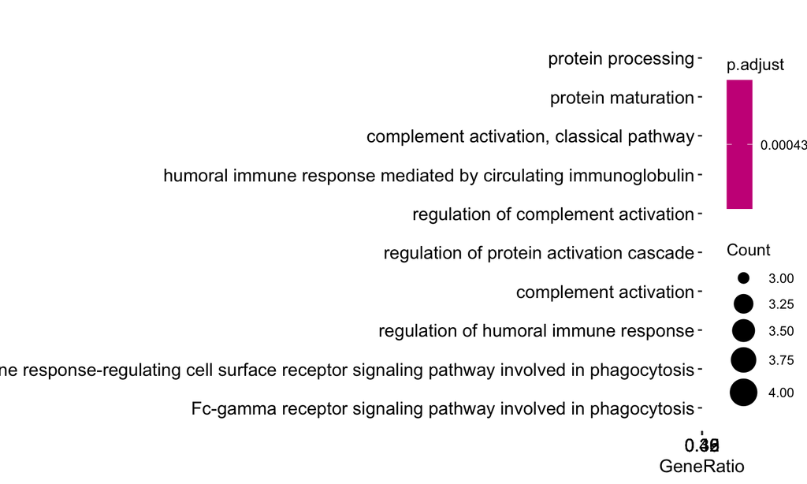

```r
dotplot(enrichment)
```

- it doesn’t look super great because we don’t have many differentially expressed genes

## Pathway analysis with clusterProfiler

- its possible, but is a little complicated. If we have time, I’ll cover it

## plotting gene expression and differential expression results

- We’ll now move into some of the common visualizations you see down stream of differnetial gene expression

## volcano plots

- while plotting volcano plots is not built into `DESeq2`, the `EnhancedVolcano` package allows you to easily plot a volcano plot with the `results` of a DESeq2 object

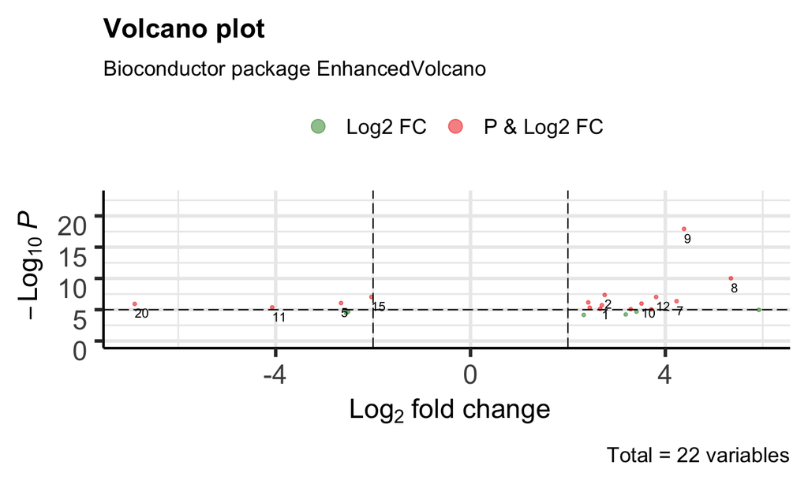

```r
library(EnhancedVolcano)
EnhancedVolcano(diff_exp_results,
                lab = rownames(diff_exp_results),
                FCcutoff = 2,
                x = 'log2FoldChange',
                y = 'pvalue')
```

## Heatmaps

- we can use the `pheatmap` package to plot a heatmap of gene expression

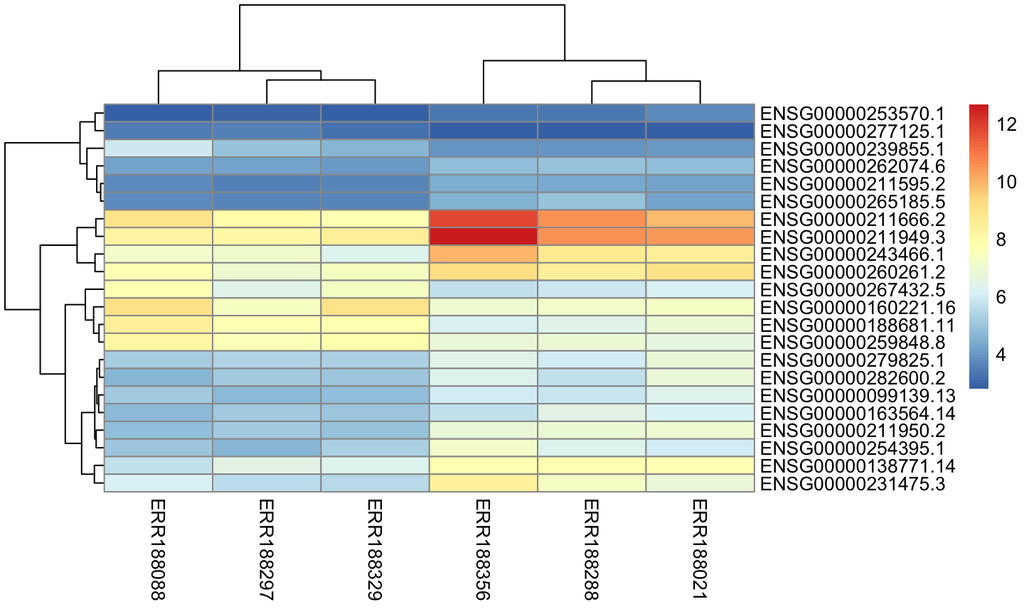

```r
library(pheatmap)
gene_Expression <-  assay(rlds)
gene_Expression_diff_exp <- gene_Expression[diff_exp_filtered$gene_id, ]
pheatmap(gene_Expression_diff_exp)
```

## A note on the results of differential expression analyses

- Any published differntial gene expression analysis has been thoroughly tuned to look the way it is
- By changing several parameters, prefiltering, pvalue cutoff, and foldchange cutoff, you can significanlty change the results of the downstream plots and gene enrichment
- Don’t get discouraged if your results don’t look exactly like you want them to. Play around with an analysis a few times to see how it will change.

## Beyond Bulk RNA-seq

- I’ll cover some other types of RNA-seq data
- Unfortunately we won’t have time to go through code for these types of RNA-seq
- However, the general workflow is the same across all types of RNA-seq
- Mapping > quantification > QC > analysis
- Bulk RNA-seq data refers to RNA generated from bulk tissue/ large quantities of RNA

## MicroRNA seq

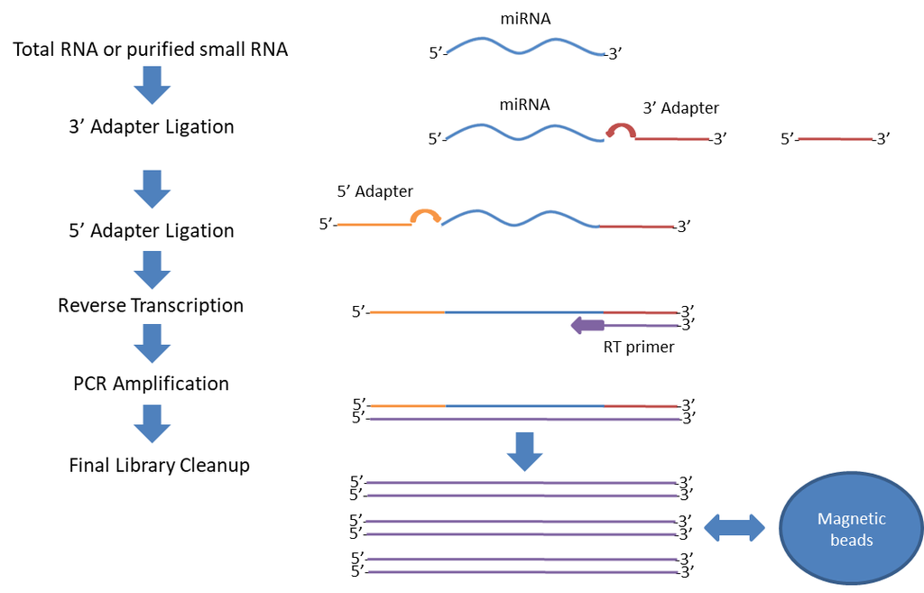

- microRNA(miRNA) are small RNAs that regulate mRNA expression, through RNA interference
- Sequencing works the exact same as bulk RNA-seq, except there is a size selection step for smaller fragments

## Well based single cell RNA-seq

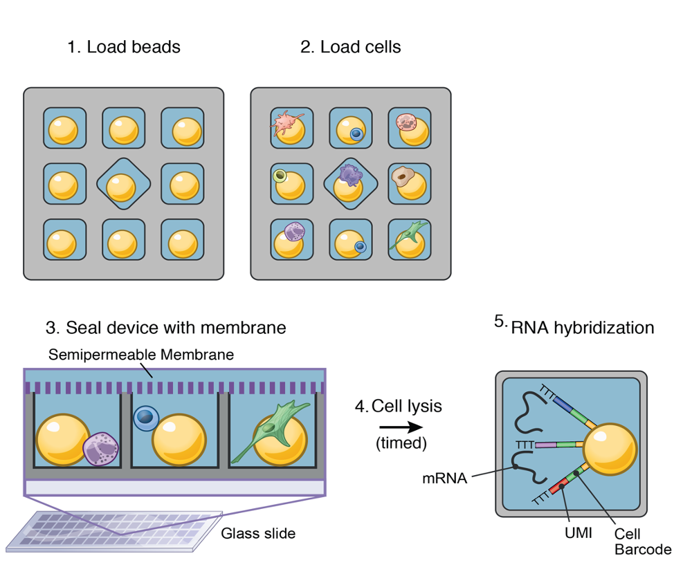

- First generation of single cell RNA-seq (scRNA-seq)
- individual cells are pipetted into wells(through serial dilution), where each well has reagents for RNA-seq library prep.
- cells are the lysed and sequenced.
- this typically yields 100-1000 individual cells cells
- Functions essentially the same as bulk RNA-seq, in that whole transcripts are amplified

## Droplet based single cell RNA-seq

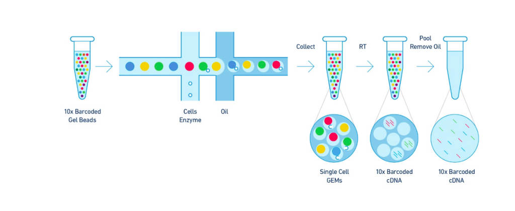

- second generation of single cell RNA-seq (scRNA-seq)
- individual cells are encapsulated in oil coated beads through a microfluidics system
- RNA-seq library preparation occurs within these droplets
- only the 3’ end of transcripts are sequenced, so can only get gene level expression for about 2000 total genes
- cells are the lysed and sequenced.
- this typically yields 5000-15000 individual cells

## Long Read RNA sequencing

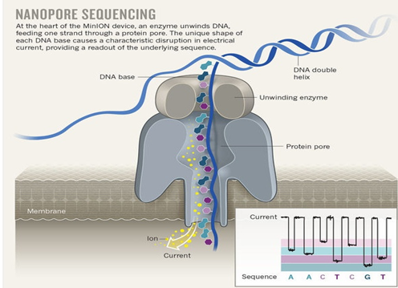

- sometimes referred to third generation RNA-sequencing
- whole RNA transcripts(300bp - 50000bp) can be directly sequenced
- Transcripts are fed through a helicase enzyme embedded in an electrically charged membrane
- as the DNA passes through the enzyme, the charge changes across the membrane, which can be used to determine the nucleotide sequence
- can be done with cDNA or direct RNA
- useful for identifying gene isoforms and RNA modifications